# Antenatal Care Utilization in Kenya

Jonah B. Neff

30 June 2025

```r
knitr::opts_chunk$set(echo = FALSE, warning = FALSE, message = FALSE)
if(!require(pacman)) install.packages("pacman")
pacman::p_load(tidyverse, here, haven, gtsummary, gt, scales)
```

# 1 Introduction to Antenatal care

Antenatal care (ANC) is a cornerstone of maternal and neonatal health. The World Health Organization recommends that pregnant women attend at least four ANC visits to monitor pregnancy progress, manage complications, and improve health outcomes for both mothers and babies.

While Kenya has made significant progress over recent decades, ANC coverage remains uneven across demographic and socioeconomic groups. Understanding which women are less likely to receive adequate ANC is crucial for informing targeted interventions and policy.

**Objectives:**  
1. Explore how age and marital status relate to ANC behavior.  
2. Visualize the proportion of women who had at least 4 ANC visits during their last pregnancy.  
3. Compare ANC utilization across education levels, residence, and wealth quintiles.  
4. Create summary tables and calculate mean ANC visits by education level.

# 2 Data and Methods

This analysis uses the most recent Kenyan Demographic and Health Survey (DHS) women’s recode dataset (KEIR72FL.DTA). The dataset includes detailed information on antenatal care utilization, household wealth, education, age, marital status, and place of residence. Data cleaning involved converting labelled variables to factors and filtering out records with missing values for antenatal care visits. A derived binary variable was created to classify whether a woman received at least four antenatal visits, following WHO recommendations. All analyses were conducted in R, using the tidyverse suite for data wrangling, ggplot2 for visualizations, and gtsummary and gt for table generation.

The presented figures and tables focus exclusively on the most recent pregnancy reported by each respondent to reflect the current state of care access and reduce recall bias related to earlier pregnancies. No weighting was applied in this descriptive analysis, in line with course guidance.

# 3 Results and Interpretation

## 3.1 Overall Proportion of 4+ ANC Visits

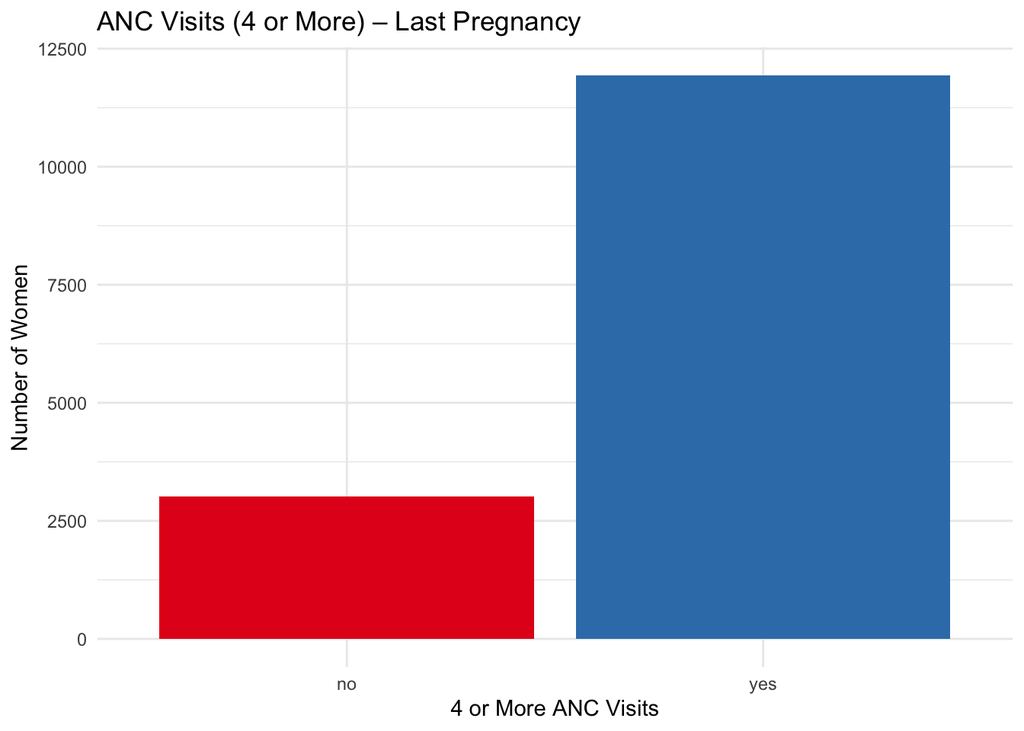

**Interpretation:**  
A substantial majority of women — approximately 80% — reported having four or more antenatal visits during their most recent pregnancy. This finding demonstrates considerable progress compared to past decades. Nevertheless, the persistence of a substantial minority of women without adequate care highlights ongoing challenges. Barriers such as long distances to facilities, indirect costs, and cultural beliefs may continue to limit universal access to recommended services. Targeted policy interventions are needed to reach these underserved populations.

## 3.2 Age Distribution by ANC 4+ Status

[interactive chart not shown]

## 3.3 ANC Coverage by Education Level

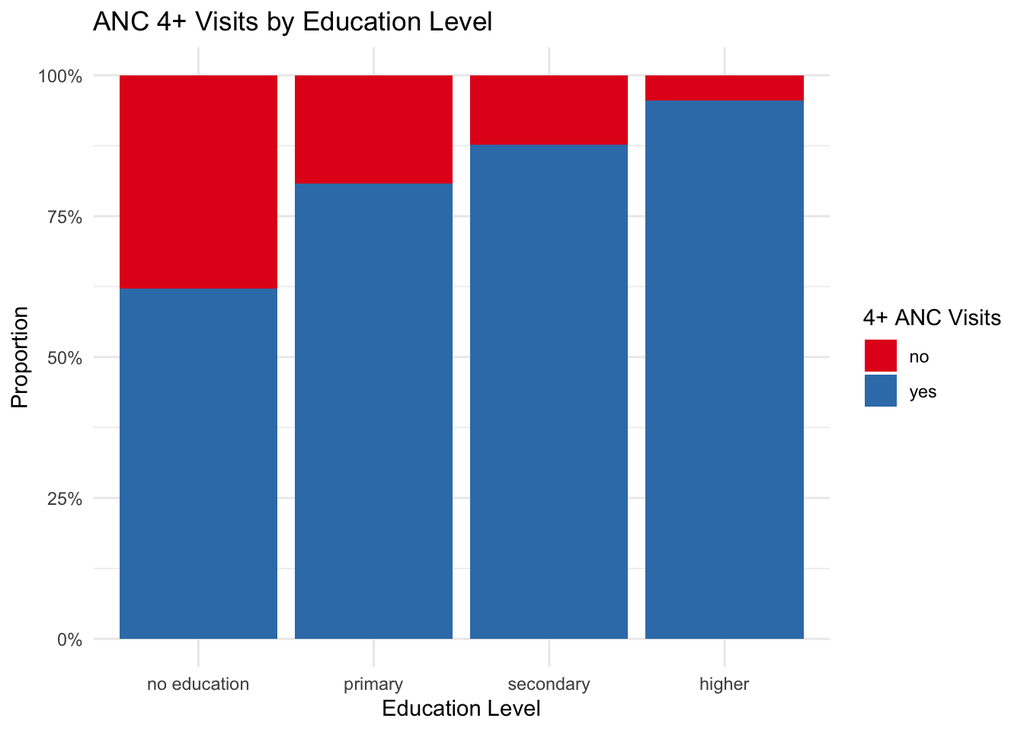

**Interpretation:**  
Education plays a significant role in ANC behavior. The chart demonstrates a clear gradient: as education increases, the proportion of women achieving adequate ANC rises substantially. Nearly all women with higher education levels met the threshold, while those with no formal education were far less likely to do so. Education likely improves awareness, empowers decision-making, and correlates with better economic opportunities. Strengthening education access for girls and women could therefore have long-term benefits for maternal health.

## 3.4 ANC Coverage by Wealth and Residence

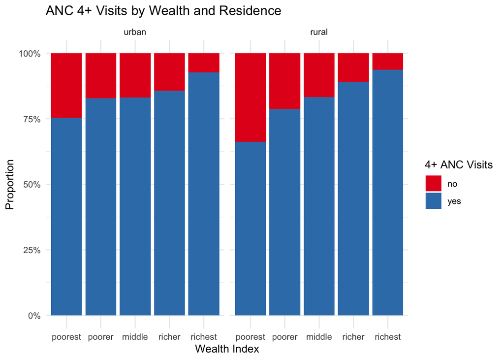

## 3.5 Summary Table (Grouped by ANC 4+ Status)

| **Variable** | **no** N = 3,008<sup>1</sup> | **yes** N = 11,937<sup>1</sup> | **p-value**<sup>2</sup> |
| --- | --- | --- | --- |
| type of place of residence |  |  | <0.001 |
| urban | 698 (23%) | 4,464 (37%) |  |
| rural | 2,310 (77%) | 7,473 (63%) |  |
| highest educational level |  |  | <0.001 |
| no education | 1,054 (35%) | 1,734 (15%) |  |
| primary | 1,508 (50%) | 6,333 (53%) |  |
| secondary | 396 (13%) | 2,814 (24%) |  |
| higher | 50 (1.7%) | 1,056 (8.8%) |  |
| wealth index |  |  | <0.001 |
| poorest | 1,471 (49%) | 3,046 (26%) |  |
| poorer | 622 (21%) | 2,422 (20%) |  |
| middle | 441 (15%) | 2,186 (18%) |  |
| richer | 310 (10%) | 2,155 (18%) |  |
| richest | 164 (5.5%) | 2,128 (18%) |  |
| respondent's current age | 29 (7) | 29 (7) | 0.9 |
| current marital status |  |  | <0.001 |
| never in union | 289 (9.6%) | 875 (7.3%) |  |
| married | 2,213 (74%) | 9,310 (78%) |  |
| living with partner | 182 (6.1%) | 624 (5.2%) |  |
| widowed | 107 (3.6%) | 270 (2.3%) |  |
| divorced | 65 (2.2%) | 229 (1.9%) |  |
| no longer living together/separated | 152 (5.1%) | 629 (5.3%) |  |

<sup>1</sup> n (%); Mean (SD)  
<sup>2</sup> Pearson’s Chi-squared test; Wilcoxon rank sum test

## 3.6 Mean ANC Visits by Education

Average Number of Antenatal Visits by Education Level

| highest educational level | mean_anc_visits |
| --- | --- |
| higher | 6.12 |
| secondary | 5.17 |
| primary | 4.73 |
| no education | 3.98 |

**Interpretation:**  
This table highlights a strong association between education and the intensity of ANC engagement. Women without any formal education averaged about 4 visits, just at the threshold, while those with higher education exceeded 6 visits. This reinforces the finding that education impacts not only whether women meet minimum recommendations but also how consistently they engage with antenatal services.

# 4 Conclusion and Limitations

This analysis shows that while ANC coverage in Kenya is relatively high overall, inequities persist. Education, wealth, and residence all influence whether women receive adequate care.

**Limitations:**

- No statistical modeling to adjust for confounders.
- Recall bias in self-reported ANC visits.
- Findings limited to the most recent pregnancy.

Future policies should prioritize improving access for disadvantaged groups, strengthening rural infrastructure, and investing in female education to sustain progress in maternal health.